# Prix de l’immobilier en Tunisie

- Carte de Tunisie avec des cercles
- Choroplèthe de la Tunisie
- Nombre d’occurrences pour chaque catégorie

## Introduction de partie 1

Le code suivant permet de créer une carte de Tunisie avec des cercles de tailles différentes indiquant les prix moyens de l’immobilier dans chaque gouvernorat. Les bibliothèques **`dplyr`**, **`maptools`**, **`sp`**, **`shapefiles`**, et **`raster`** sont chargées et utilisées pour importer des données et créer la carte. Un dataframe est créé à partir des coordonnées des centroides des gouvernorats et des données sur les prix moyens de l’immobilier, puis utilisé pour calculer la taille des cercles sur la carte. Enfin, la carte est tracée avec une légende indiquant les différentes tailles de cercles et leurs valeurs correspondantes en termes de prix moyen de l’immobilier.

Charger les bibliothèques nécessaires

```r
setwd("C:\\Users\\ferja\\Desktop\\Analyse\\tunisia")
library(dplyr)
library(maptools)
library(sp)
library(shapefiles)
library(raster)
```

Importation de cartographie de la Tunisie

```r
fdc<- getData(name="GADM", country="TUN", level=1)
fdc
```

```
class       : SpatialPolygonsDataFrame
features    : 24
extent      : 7.530076, 11.59826, 30.23681, 37.55986  (xmin, xmax, ymin, ymax)
crs         : +proj=longlat +datum=WGS84
variables   : 10
names       : GID_0,  NAME_0,   GID_1,   NAME_1,                                    VARNAME_1, NL_NAME_1,  TYPE_1,   ENGTYPE_1, CC_1, HASC_1
min values  :   TUN, Tunisia, TUN.1_1,   Ariana, Al Aryiānah|L'Ariana|Tunis Ariana|Al Aryānah,        NA, Wilayat, Governorate,   NA,  TN.AN
max values  :   TUN, Tunisia, TUN.9_1, Zaghouan,  Tunis South|Zachouan|Zaguan|Zaghwān|Saghuan,        NA, Wilayat, Governorate,   NA,  TN.ZA
```

Importation des données

```r
data <- read.csv("data.csv")
data
```

| city | avg_price |
| --- | --- |
| Ariana | 946 |
| Béja | 362 |
| Ben Arous (Tunis Sud) | 788 |
| Bizerte | 506 |
| Gabès | 374 |
| Gafsa | 346 |
| Jendouba | 360 |
| Kairouan | 814 |
| Kassérine | 352 |
| Kebili | 300 |

[output cut: 14 more lines]

Extraction des coordonnées des centroides des gouvernorats

```r
pt <- cbind(fdc@data[, "NAME_1"], as.data.frame(coordinates(fdc)))
```

Jointure entre le dataframe des coordonnées des centroides et les données à cartographier

```r
pt <- data.frame(pt, data$avg_price)
colnames(pt) <- c("id", "x", "y", "avg_price")
i=match(pt[, "id"], unlist(data[, "city"]))
pt <- data.frame(pt, data[i, ])
pt$var <- pt$avg_price
```

Calcul du rayon des cercles.

```r
x1 <- bbox(fdc)[1]
y1 <- bbox(fdc)[2]
x2 <- bbox(fdc)[3]
y2 <- bbox(fdc)[4]
```

Surface maximale de la carte

```r
sfdc <- (x2 - x1) * (y2 - y1)
```

Somme de la variable à cartographier

```r
sc <- sum(pt$var, na.rm = TRUE)
sc
```

```
[1] 13010
```

```r
k <- 0.1
pt$size <- sqrt((pt$var * k * sfdc/sc)/pi)
```

Enfin on trace la carte

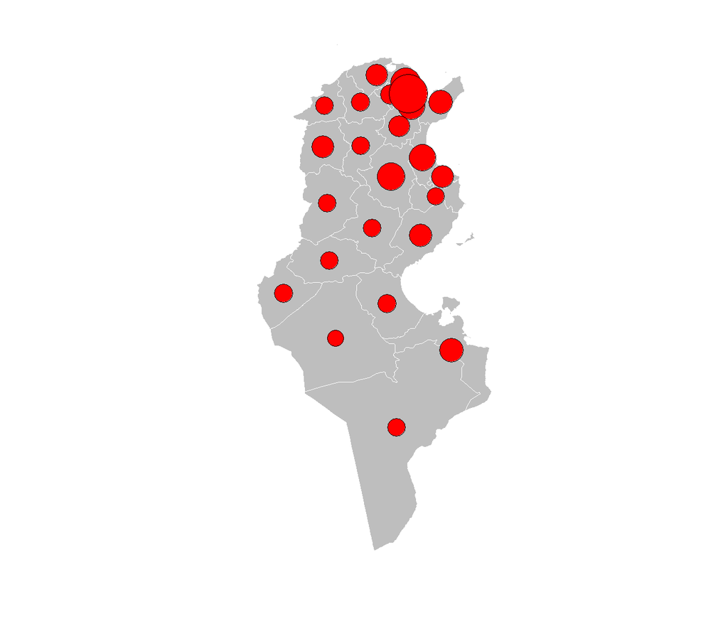

```r
plot(fdc, border = "white", col = "grey")
symbols(pt[, c("x", "y")], circles = pt$size, add = TRUE, bg = "red", inches = FALSE)
```

Ajout d’une légende sur la carte

```r
plot(fdc, border = "white", col = "grey")
symbols(pt[, c("x", "y")], circles = pt$size, add = TRUE, bg = "red", inches = FALSE)
```

```r
LegTitle <- "Prix"
rLeg <- quantile(pt$size, c(1, 0.9, 0), type = 1, na.rm = TRUE)
rVal <- quantile(pt$var, c(1, 0.9, 0), type = 1, na.rm = TRUE)
l <- data.frame(x = x1, y = y1)
xinit <- l$x + rLeg[1]
ypos <- l$y + rLeg
symbols(x = rep(xinit, 3), y = ypos, circles = rLeg, add = TRUE, bg = "red", inches = FALSE)
text(x = rep(xinit, 3) + rLeg[1] * 1.2, y = (l$y + (2 * rLeg)), rVal, cex = 0.9, srt = 0, adj = 0)
```

```r
for (i in 1:3) {
 segments(xinit, (l$y + (1.8 * rLeg[i])), xinit + rLeg[1] * 1.1, (l$y + (1.8 * rLeg[i])))
}

text(x = xinit - rLeg[1], y = (l$y + (2 * rLeg[1])), LegTitle, adj = c(0, 0),cex = 1)
```

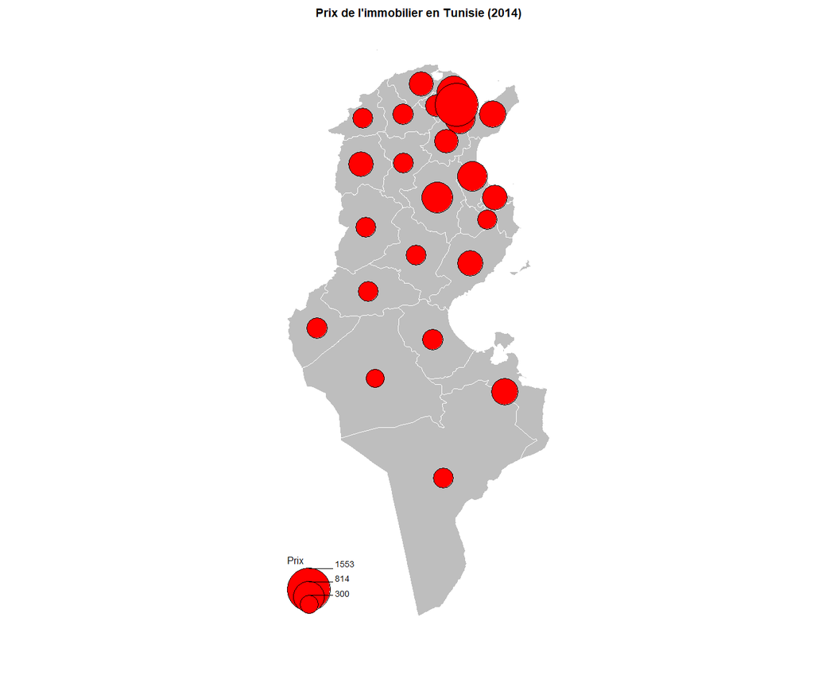

```r
title(main = "Prix de l'immobilier en Tunisie (2014)",  cex.sub = 0.7)
```

## Introduction de partie 2

Ce code crée un choroplèthe de la Tunisie en utilisant des données géographiques et des données de prix moyen des biens immobiliers. Les bibliothèques requises sont chargées, puis les données sont obtenues et lues à partir d’un fichier CSV. Un message contextuel est créé pour afficher les informations de ville et de prix sur chaque polygone, et une palette de couleurs est utilisée pour colorer les polygones en fonction des données de prix. Enfin, la carte est créée et affichée avec un titre HTML et une légende.

Charger les bibliothèques requises

```r
library(leaflet)
library(raster)
library(htmlwidgets)
```

Obtenir les données géographiques pour la Tunisie au premier niveau administratif

```r
tun <- getData("GADM", country="TUN", level=1)
```

Lire les données de prix moyen à partir d’un fichier CSV

```r
data <- read.csv("data.csv")
# Ajouter les données de prix moyen à l'objet de données Tunisie
tun$data <- data$avg_price
```

Créer un message contextuel qui affiche la ville et les données de prix moyen

```r
polygon_popup <- paste0("<strong>Ville : </strong>", tun$NAME_1, "<br>",
                        "<strong>Prix : </strong>", round(tun$data,2))
```

Créer une palette de couleurs en utilisant un schéma de couleurs personnalisé et un domaine

```r
pal <- colorNumeric(
  palette = c("#00ff00", "#ff0000"),
  domain = tun$data
)
```

Créer un titre HTML

```r
title_html = "<div style='text-align: center; font-weight: bold;'>Prix de l'immobilier en Tunisie (2014)</div>"
```

Créer l’objet carte

```r
map = leaflet() %>%
  # addProviderTiles("CartoDB.Positron") %>%
  # Définir la vue initiale sur la Tunisie, zoomée au niveau 6
  setView(9.5, 33.9, zoom = 7) %>%
  # Ajouter le titre HTML à la carte
  addControl(title_html, position = "topleft") %>%
  # Ajouter des polygones à la carte, colorés par les données de prix moyen
  addPolygons(data = tun,
              fillColor= ~pal(data),
              fillOpacity = 0.4,
              weight = 2,
              color = "white",
              popup = polygon_popup)%>%
  # Ajouter une légende à la carte
  addLegend("bottomright", pal = pal, values = tun$data,
            title = "Prix en TND (2014)",
            opacity = 1)

# Afficher la carte
map
```

[interactive chart not shown]

## Introduction de partie 3

Ce code lit les données du fichier “Property_Prices_in_Tunisia.csv” et filtre les prix supérieurs à 10000.0 et les types d’annonces “À Vendre”. Il enlève également les terrains et fermes de la liste des données. Ensuite, il groupe les données par catégorie et calcule le nombre d’occurrences de chaque catégorie. Les données sont triées en ordre décroissant selon le nombre d’occurrences et un graphique en barres montrant le nombre d’occurrences pour chaque catégorie est créé.

Lire les données et les nettoyer

```r
data <- read.csv("Property_Prices_in_Tunisia.csv")
data <- data[!data$price %in% subset(data$price, data$price > 10000.0),]
data <- data[!data$type %in% subset(data$type, data$type == "À Vendre"),]
data <- filter(data, category != "Terrains et Fermes")
```

Groupe les données par catégorie

```r
data_grouped <- group_by(data, category)
data_summary <- summarize(data_grouped, occurrence = n())
data_summary
```

| category | occurrence |
| --- | --- |
| Appartements | 2780 |
| Bureaux et Plateaux | 383 |
| Colocations | 60 |
| Locations de vacances | 293 |
| Magasins, Commerces et Locaux industriels | 344 |
| Maisons et Villas | 1032 |

Trie les données par ordre décroissant en fonction du nombre d’occurrences

```r
data_summary <- data_summary[order(-data_summary$occurrence),]
```

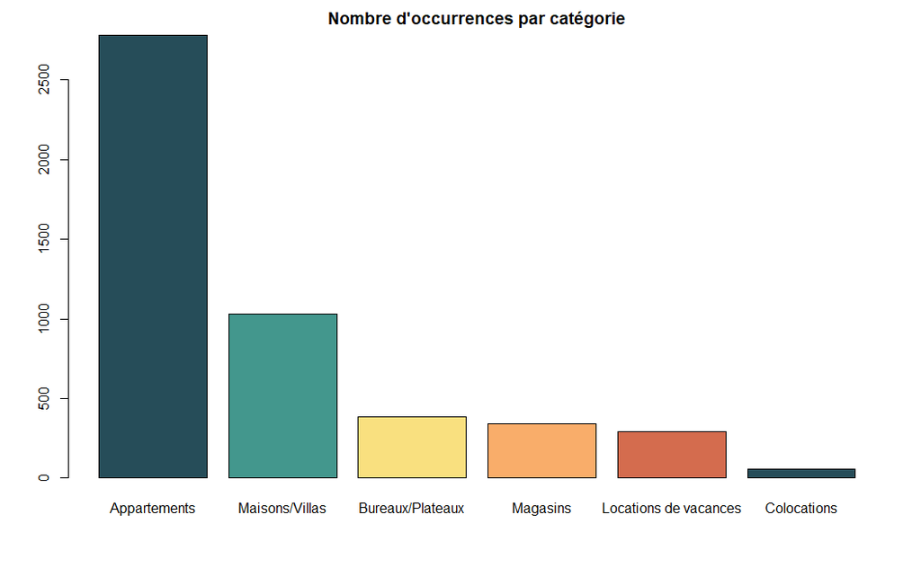

```r
barplot(data_summary$occurrence, names.arg = c('Appartements', 'Maisons/Villas', 'Bureaux/Plateaux', 'Magasins', 'Locations de vacances', 'Colocations'), col = c("#264D59", "#43978D", "#F9E07F", "#F9AD6A", "#D46C4E"))
title("Nombre d'occurrences par catégorie")
```

```r
# xlab("Catégorie")
# ylab("Pourcentage d'occurrences")
```

## Github

https://github.com/stormynight9/property-price-tunisia

[figure not shown]